# Ejemplo Tyrell Corp 2: Análisis de Crecimiento de Replicantes Nexus-4 (Módulo B)

Regresiones no lineales - Modelo de Gompertz

Javi Cantón-Correa

[figure not shown]

## 1. Introducción

En este segundo análisis, como parte del departamento de investigación de Tyrell Corporation, estudiamos el comportamiento de una población de replicantes Nexus-4 en un módulo de privación sensorial alternativo (Módulo B). Este estudio complementa nuestros hallazgos previos y nos permite explorar diferentes patrones de adaptación y crecimiento en entornos controlados.

## 2. Simulación del escenario experimental

En nuestro laboratorio de Dubai, hemos observado el crecimiento del número de replicantes en un entorno con características diferentes al módulo anterior. La evolución muestra un patrón de crecimiento exponencial con saturación gradual, un comportamiento que requiere un enfoque de modelado diferente.

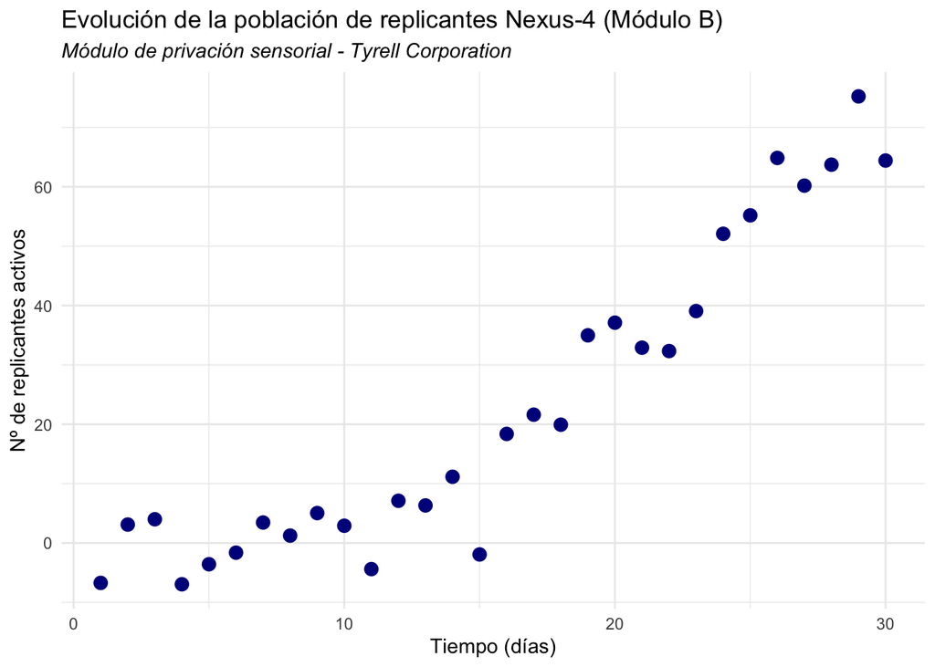

```r
set.seed(456)
tiempo <- 1:30
# Generamos datos con forma de Gompertz + ruido (aumentado)
replicantes <- 80 * exp(-exp(-0.2 * (tiempo - 20))) + rnorm(30, mean = 0, sd = 5)

# Representación de los datos
ggplot(data.frame(tiempo, replicantes), aes(x = tiempo, y = replicantes)) +
  geom_point(color = "darkblue", size = 3) +
  labs(title = "Evolución de la población de replicantes Nexus-4 (Módulo B)",
       subtitle = "Módulo de privación sensorial - Tyrell Corporation",
       x = "Tiempo (días)",
       y = "Nº de replicantes activos") +
  theme_minimal() +
  theme(plot.subtitle = element_text(face = "italic"))
```

## 3. Análisis inicial con regresión lineal

Como primer enfoque, intentamos modelar el crecimiento con una regresión lineal, siguiendo nuestro protocolo estándar.

```r
modelo_lineal <- lm(replicantes ~ tiempo)
summary(modelo_lineal)
```

```
##
## Call:
## lm(formula = replicantes ~ tiempo)
##
## Residuals:
##     Min      1Q  Median      3Q     Max
## -23.597  -5.914   1.480   5.693  17.102
##
## Coefficients:
##             Estimate Std. Error t value Pr(>|t|)
## (Intercept) -19.4799     3.5364  -5.508 6.92e-06 ***
## tiempo        2.7435     0.1992  13.773 5.41e-14 ***
## ---
## Signif. codes:  0 '***' 0.001 '**' 0.01 '*' 0.05 '.' 0.1 ' ' 1
##
## Residual standard error: 9.444 on 28 degrees of freedom
## Multiple R-squared:  0.8714, Adjusted R-squared:  0.8668
## F-statistic: 189.7 on 1 and 28 DF,  p-value: 5.406e-14
```

```r
# Interpretación de métricas
cat("\nInterpretación del modelo lineal:\n")
```

```
##
## Interpretación del modelo lineal:
```

```r
cat("R² =", round(summary(modelo_lineal)$r.squared, 3), "\n")
```

```
## R² = 0.871
```

```r
cat("R² ajustado =", round(summary(modelo_lineal)$adj.r.squared, 3), "\n")
```

```
## R² ajustado = 0.867
```

```r
cat("Error estándar residual =", round(summary(modelo_lineal)$sigma, 3), "\n")
```

```
## Error estándar residual = 9.444
```

```r
cat("F-statistic =", round(summary(modelo_lineal)$fstatistic[1], 3), "\n")
```

```
## F-statistic = 189.685
```

```r
cat("p-value =", format.pval(pf(summary(modelo_lineal)$fstatistic[1],
                               summary(modelo_lineal)$fstatistic[2],
                               summary(modelo_lineal)$fstatistic[3],
                               lower.tail = FALSE), digits = 3), "\n")
```

```
## p-value = 5.41e-14
```

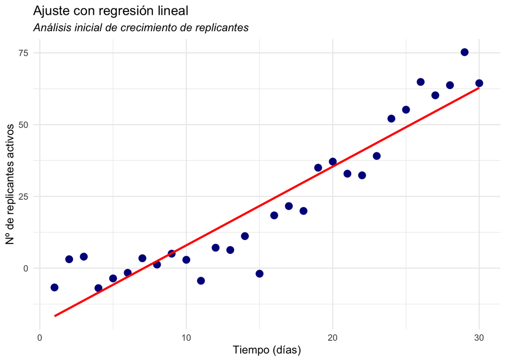

```r
# Visualización del modelo lineal
ggplot(data.frame(tiempo, replicantes), aes(x = tiempo, y = replicantes)) +
  geom_point(color = "darkblue", size = 3) +
  geom_smooth(method = "lm", color = "red", se = FALSE) +
  labs(title = "Ajuste con regresión lineal",
       subtitle = "Análisis inicial de crecimiento de replicantes",
       x = "Tiempo (días)",
       y = "Nº de replicantes activos") +
  theme_minimal() +
  theme(plot.subtitle = element_text(face = "italic"))
```

> **Interpretación de métricas**: - El R² de 0.871 indica que el modelo lineal explica el 87.1% de la variabilidad en los datos - El error estándar residual de 9.444 sugiere una desviación promedio significativa - Aunque el F-statistic es significativo (p < 0.001), el modelo no captura la curvatura de los datos - Los residuales muestran un patrón sistemático, indicando que el modelo lineal es inadecuado

> **Explicación matemática**: El modelo lineal asume un crecimiento constante, siguiendo la ecuación:
> $$y = a + b \cdot t$$

> **Explicación intuitiva**: Imagina que cada día llega un número fijo de nuevos replicantes al módulo, como si fuera una línea de producción constante. Este modelo es como una máquina que produce siempre la misma cantidad, sin importar cuántos replicantes haya ya en el módulo. Es demasiado simple para capturar la realidad, donde el crecimiento se ralentiza cuando el espacio se llena.

## 4. Ajuste con regresión polinómica de grado 2

Basándonos en nuestros estudios previos, probamos un modelo polinomial de grado 2.

```r
modelo_poly2 <- lm(replicantes ~ poly(tiempo, 2, raw = TRUE))
summary(modelo_poly2)
```

```
##
## Call:
## lm(formula = replicantes ~ poly(tiempo, 2, raw = TRUE))
##
## Residuals:
##      Min       1Q   Median       3Q      Max
## -15.6972  -2.5845  -0.1513   3.9572   9.2768
##
## Coefficients:
##                              Estimate Std. Error t value Pr(>|t|)
## (Intercept)                  -1.98640    3.55808  -0.558    0.581
## poly(tiempo, 2, raw = TRUE)1 -0.53653    0.52910  -1.014    0.320
## poly(tiempo, 2, raw = TRUE)2  0.10581    0.01656   6.389 7.64e-07 ***
## ---
## Signif. codes:  0 '***' 0.001 '**' 0.01 '*' 0.05 '.' 0.1 ' ' 1
##
## Residual standard error: 6.068 on 27 degrees of freedom
## Multiple R-squared:  0.9488, Adjusted R-squared:  0.945
## F-statistic: 250.1 on 2 and 27 DF,  p-value: < 2.2e-16
```

```r
# Interpretación de métricas
cat("\nInterpretación del modelo polinomial de grado 2:\n")
```

```
##
## Interpretación del modelo polinomial de grado 2:
```

```r
cat("R² =", round(summary(modelo_poly2)$r.squared, 3), "\n")
```

```
## R² = 0.949
```

```r
cat("R² ajustado =", round(summary(modelo_poly2)$adj.r.squared, 3), "\n")
```

```
## R² ajustado = 0.945
```

```r
cat("Error estándar residual =", round(summary(modelo_poly2)$sigma, 3), "\n")
```

```
## Error estándar residual = 6.068
```

```r
cat("F-statistic =", round(summary(modelo_poly2)$fstatistic[1], 3), "\n")
```

```
## F-statistic = 250.133
```

```r
cat("p-value =", format.pval(pf(summary(modelo_poly2)$fstatistic[1],
                               summary(modelo_poly2)$fstatistic[2],
                               summary(modelo_poly2)$fstatistic[3],
                               lower.tail = FALSE), digits = 3), "\n")
```

```
## p-value = <2e-16
```

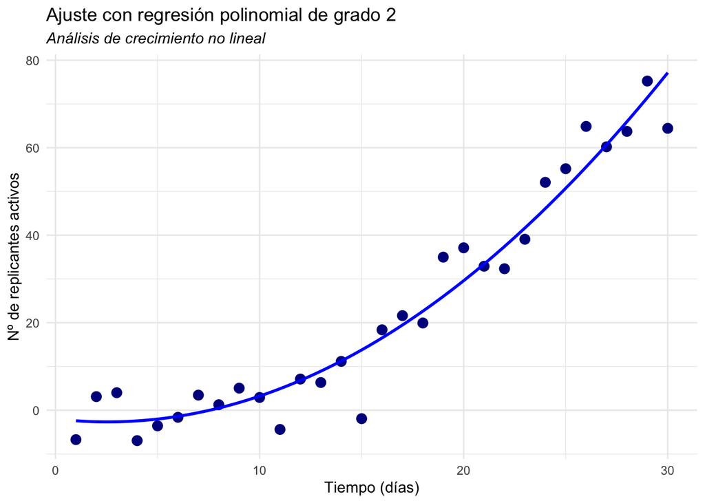

```r
# Visualización del modelo polinomial de grado 2
ggplot(data.frame(tiempo, replicantes), aes(x = tiempo, y = replicantes)) +
  geom_point(color = "darkblue", size = 3) +
  geom_smooth(method = "lm", formula = y ~ poly(x, 2), color = "blue", se = FALSE) +
  labs(title = "Ajuste con regresión polinomial de grado 2",
       subtitle = "Análisis de crecimiento no lineal",
       x = "Tiempo (días)",
       y = "Nº de replicantes activos") +
  theme_minimal() +
  theme(plot.subtitle = element_text(face = "italic"))
```

> **Explicación matemática**: El modelo polinomial de grado 2 introduce curvatura mediante:
> $$y =
> a + b \cdot t + c \cdot t^2$$

## 5. Implementación del modelo de Gompertz

Inspirados por nuestros estudios en Shanghai, implementamos un modelo de Gompertz que ha demostrado ser efectivo para capturar patrones de crecimiento con saturación gradual.

```r
# Ajuste del modelo de Gompertz
modelo_gompertz <- nls(replicantes ~ A * exp(-exp(-k*(tiempo - t0))),
                      start = list(A = 80, k = 0.2, t0 = 20),
                      data = data.frame(tiempo, replicantes))

summary(modelo_gompertz)
```

```
##
## Formula: replicantes ~ A * exp(-exp(-k * (tiempo - t0)))
##
## Parameters:
##    Estimate Std. Error t value Pr(>|t|)
## A  93.73835   16.65679   5.628 5.67e-06 ***
## k   0.13606    0.03194   4.260 0.000222 ***
## t0 20.61392    1.59698  12.908 4.59e-13 ***
## ---
## Signif. codes:  0 '***' 0.001 '**' 0.01 '*' 0.05 '.' 0.1 ' ' 1
##
## Residual standard error: 5.464 on 27 degrees of freedom
##
## Number of iterations to convergence: 5
## Achieved convergence tolerance: 8.592e-07
```

```r
# Interpretación de métricas
cat("\nInterpretación del modelo de Gompertz:\n")
```

```
##
## Interpretación del modelo de Gompertz:
```

```r
cat("Suma de cuadrados residual =", round(sum(residuals(modelo_gompertz)^2), 3), "\n")
```

```
## Suma de cuadrados residual = 806.19
```

```r
cat("Error estándar de los parámetros:\n")
```

```
## Error estándar de los parámetros:
```

```r
print(summary(modelo_gompertz)$parameters[, "Std. Error"])
```

```
##           A           k          t0
## 16.65678751  0.03194125  1.59698284
```

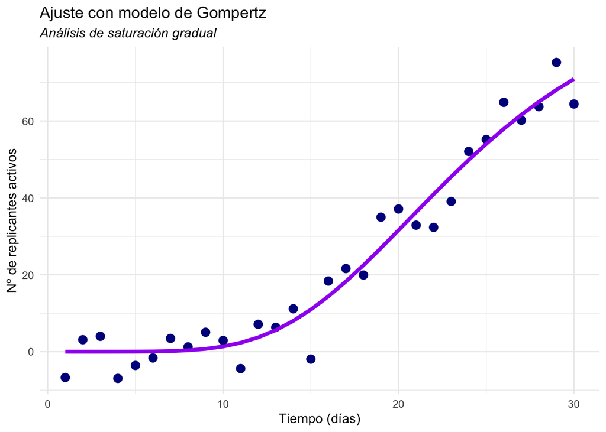

```r
# Visualización del modelo de Gompertz
pred_gompertz <- predict(modelo_gompertz)

ggplot(data.frame(tiempo, replicantes), aes(x = tiempo, y = replicantes)) +
  geom_point(color = "darkblue", size = 3) +
  geom_line(aes(y = pred_gompertz), color = "purple", size = 1.5) +
  labs(title = "Ajuste con modelo de Gompertz",
       subtitle = "Análisis de saturación gradual",
       x = "Tiempo (días)",
       y = "Nº de replicantes activos") +
  theme_minimal() +
  theme(plot.subtitle = element_text(face = "italic"))
```

> **Explicación matemática**: El modelo de Gompertz describe el crecimiento con saturación gradual mediante:
> $$y = A \cdot e^{-e^{-k(t-t_0)}}$$

## 6. Análisis con splines

Como complemento a nuestros estudios, aplicamos splines para capturar patrones locales en el crecimiento.

```r
# Ajuste con splines
library(splines)
modelo_splines <- lm(replicantes ~ bs(tiempo, df = 5))
summary(modelo_splines)
```

```
##
## Call:
## lm(formula = replicantes ~ bs(tiempo, df = 5))
##
## Residuals:
##      Min       1Q   Median       3Q      Max
## -13.2744  -3.1669   0.6085   3.7217   8.6972
##
## Coefficients:
##                     Estimate Std. Error t value Pr(>|t|)
## (Intercept)           -3.382      4.659  -0.726  0.47490
## bs(tiempo, df = 5)1    5.528      9.315   0.594  0.55839
## bs(tiempo, df = 5)2   -2.054      7.037  -0.292  0.77290
## bs(tiempo, df = 5)3   31.769      8.834   3.596  0.00145 **
## bs(tiempo, df = 5)4   70.216      7.331   9.578 1.13e-09 ***
## bs(tiempo, df = 5)5   72.456      6.708  10.801 1.07e-10 ***
## ---
## Signif. codes:  0 '***' 0.001 '**' 0.01 '*' 0.05 '.' 0.1 ' ' 1
##
## Residual standard error: 5.685 on 24 degrees of freedom
## Multiple R-squared:   0.96,  Adjusted R-squared:  0.9517
## F-statistic: 115.3 on 5 and 24 DF,  p-value: 5.675e-16
```

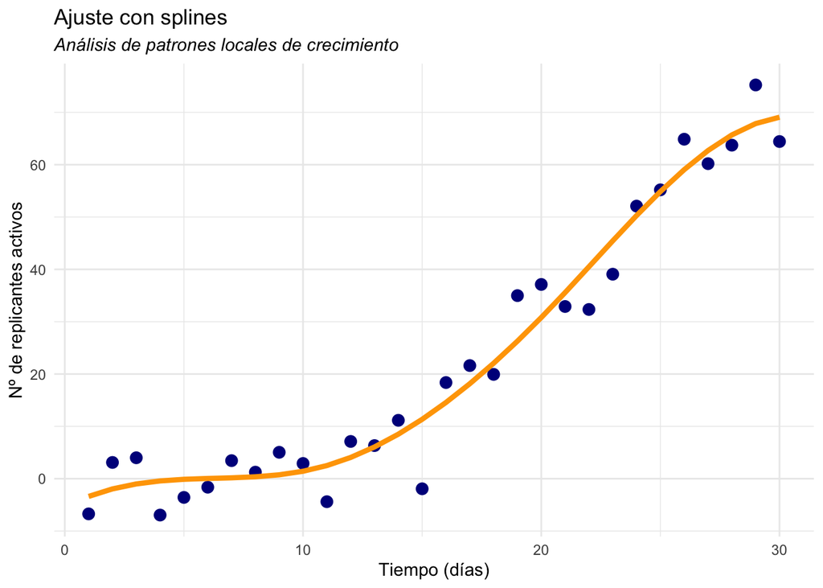

```r
# Visualización del modelo con splines
pred_splines <- predict(modelo_splines)

ggplot(data.frame(tiempo, replicantes), aes(x = tiempo, y = replicantes)) +
  geom_point(color = "darkblue", size = 3) +
  geom_line(aes(y = pred_splines), color = "orange", size = 1.5) +
  labs(title = "Ajuste con splines",
       subtitle = "Análisis de patrones locales de crecimiento",
       x = "Tiempo (días)",
       y = "Nº de replicantes activos") +
  theme_minimal() +
  theme(plot.subtitle = element_text(face = "italic"))
```

> **Interpretación de métricas**: - Los splines ofrecen gran flexibilidad en el ajuste - El error residual (5.685) es comparable al modelo de Gompertz (5.464) - Los grados de libertad son mayores que en otros modelos - Requiere interpretación cuidadosa de los resultados

> **Explicación matemática**: Los splines dividen el rango de tiempo en segmentos y ajustan polinomios locales en cada segmento, conectándolos suavemente. Matemáticamente:
> $$y = \sum_{i=1}^{n} \beta_i B_i(t)$$

> **Explicación intuitiva**: Los splines son como un artista que dibuja una curva suave usando varias reglas flexibles. Cada regla se ajusta a una parte de la curva, y donde se unen las reglas, la transición es suave. Es como si dividiéramos el crecimiento en “etapas” y ajustáramos cada etapa por separado, asegurándonos de que la transición entre etapas sea natural. Este enfoque es muy flexible y puede capturar patrones complejos, pero es más difícil de interpretar en términos biológicos.

## 7. Comparación de modelos

Realizamos una comparación exhaustiva de los modelos para determinar el enfoque más adecuado.

```r
# Calculamos métricas para cada modelo
metricas <- data.frame(
  Modelo = c("Lineal", "Polinomial (grado 2)", "Gompertz", "Splines"),
  R2 = c(
    summary(modelo_lineal)$r.squared,
    summary(modelo_poly2)$r.squared,
    NA,  # No aplicable para modelo de Gompertz
    summary(modelo_splines)$r.squared
  ),
  R2_ajustado = c(
    summary(modelo_lineal)$adj.r.squared,
    summary(modelo_poly2)$adj.r.squared,
    NA,
    summary(modelo_splines)$adj.r.squared
  ),
  Error_Residual = c(
    summary(modelo_lineal)$sigma,
    summary(modelo_poly2)$sigma,
    sqrt(sum(residuals(modelo_gompertz)^2)/df.residual(modelo_gompertz)),
    summary(modelo_splines)$sigma
  ),
  AIC = c(
    AIC(modelo_lineal),
    AIC(modelo_poly2),
    AIC(modelo_gompertz),
    AIC(modelo_splines)
  ),
  BIC = c(
    BIC(modelo_lineal),
    BIC(modelo_poly2),
    BIC(modelo_gompertz),
    BIC(modelo_splines)
  )
)

# Visualización de la tabla de métricas
print(metricas)
```

```
##                 Modelo        R2 R2_ajustado Error_Residual      AIC      BIC
## 1               Lineal 0.8713738   0.8667800       9.443571 223.7866 227.9902
## 2 Polinomial (grado 2) 0.9487924   0.9449993       6.067863 198.1559 203.7607
## 3             Gompertz        NA          NA       5.464329 191.8700 197.4748
## 4              Splines 0.9600443   0.9517202       5.685052 196.7124 206.5208
```

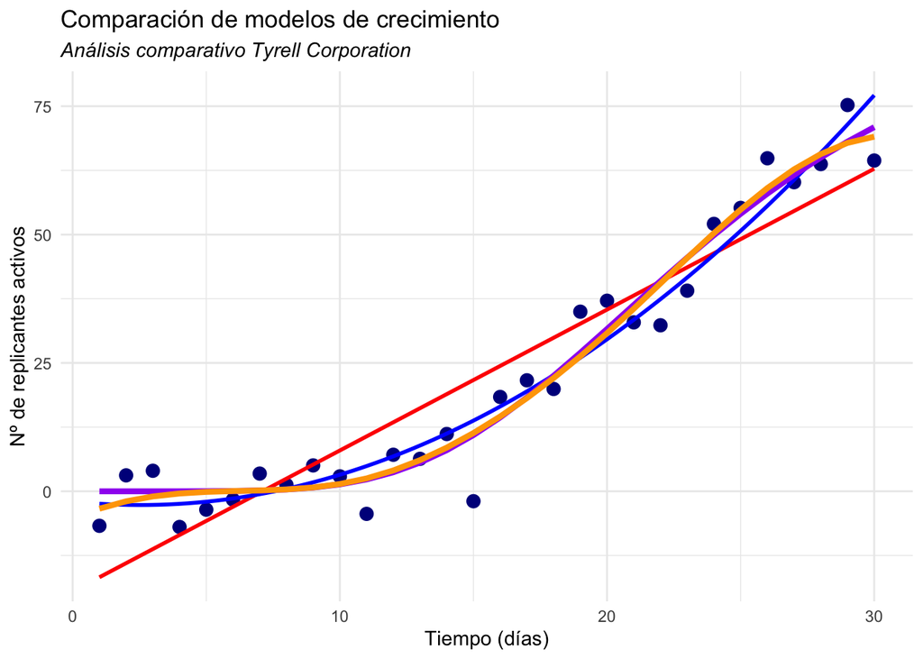

```r
# Visualización de todos los modelos
ggplot(data.frame(tiempo, replicantes), aes(x = tiempo, y = replicantes)) +
  geom_point(color = "darkblue", size = 3) +
  geom_smooth(method = "lm", color = "red", se = FALSE) +
  geom_smooth(method = "lm", formula = y ~ poly(x, 2), color = "blue", se = FALSE) +
  geom_line(aes(y = pred_gompertz), color = "purple", size = 1.5) +
  geom_line(aes(y = pred_splines), color = "orange", size = 1.5) +
  labs(title = "Comparación de modelos de crecimiento",
       subtitle = "Análisis comparativo Tyrell Corporation",
       x = "Tiempo (días)",
       y = "Nº de replicantes activos") +
  theme_minimal() +
  theme(plot.subtitle = element_text(face = "italic")) +
  scale_color_manual(values = c("red", "blue", "purple", "orange"),
                    labels = c("Lineal", "Polinomial (grado 2)", "Gompertz", "Splines"))
```

> **Análisis comparativo de métricas**:
> 1. **R² y R² ajustado**:
>    - El modelo lineal tiene un ajuste moderado (R² = 0.871)
>    - El modelo polinomial de grado 2 mejora significativamente (R² = 0.949)
>    - Los splines tienen un alto ajuste (R² = 0.960), aunque no necesariamente el “mejor” si consideramos otros criterios.
> 2. **Error Residual**:
>    - El modelo lineal tiene un error de 9.444
>    - El modelo polinomial de grado 2 reduce el error a 6.068
>    - El modelo de Gompertz tiene el menor error (5.464)
>    - Los splines tienen un error similar (5.685)
> 3. **AIC y BIC**:
>    - El modelo lineal tiene valores de AIC = 223.79, BIC = 227.99
>    - El modelo polinomial de grado 2 mejora a AIC = 198.16, BIC = 203.76
>    - El modelo de Gompertz tiene los mejores valores de AIC = 191.87, BIC = 197.47
>    - Los splines tienen valores de AIC = 196.71, BIC = 206.52
> 4. **Interpretabilidad**:
>    - El modelo de Gompertz tiene parámetros con significado biológico claro
>    - Los modelos polinomiales son más difíciles de interpretar
>    - Los splines, aunque tienen buen ajuste, son difíciles de interpretar

## 8. Discusión

- **Modelo Lineal**: Simple pero inadecuado para datos con crecimiento exponencial y saturación
- **Modelo Polinomial (grado 2)**: Mejora el ajuste pero sigue siendo limitado para capturar la dinámica completa
- **Modelo de Gompertz**: Captura excelentemente la dinámica de crecimiento y saturación gradual
- **Splines**: Ofrecen flexibilidad pero requieren interpretación cuidadosa

## 9. Conclusiones y Recomendaciones

Este análisis, complementario a nuestros estudios previos, demuestra que el modelo de Gompertz es el más apropiado para predecir el comportamiento de los replicantes Nexus-4 en el Módulo B. Recomendamos:

1. Implementar el modelo de Gompertz como estándar para análisis de crecimiento en módulos con saturación gradual
2. Utilizar el modelo polinomial de grado 2 como alternativa cuando se requiera mayor flexibilidad
3. Mantener los splines como herramienta complementaria para análisis de patrones locales
4. Continuar el monitoreo y ajuste de los parámetros según evolucione la población de replicantes

Estos hallazgos enriquecen nuestra comprensión de la dinámica de poblaciones de replicantes y mejorarán nuestros protocolos de control y predicción en todas las instalaciones de Tyrell Corporation.